# Project2_FirstDraft

Introduction (20 points)

- 5 points for specific, measurable, and clear scientific question
- 5 points for background on the protein/gene/species of interest and where the data is sourced from
- 5 points for clear, specific, and measurable scientific hypothesis that is in the form of an if-then statement
- 5 points for description of what analyses were done and how the data was downloaded for the project

#### Scientific question:

WISP-1 is a protein from the CCN protein family which is known to act as an oncogene in most type of cancers to promote cancer cell proliferation, progression, metastasis, and invasion. What might be the structural basis of WISP-1-induced tumor growth?

#### Background

WNT1 inducible signaling pathway protein 1 (WISP1), a member 4 protein from the CCN family (CCN4), is a secreted matricellular protein found in the extracellular matrix (ECM) and affects different cell responses like other ECM proteins. It plays a part in cellular functions such as differentiation, proliferation, migration, and survival. and was demonstrated to its overexpression has oncogenic properties in most cancers. An in vitro study found that recombinant WISP-1 treatment increased cell proliferation in a breast cancer context (1). Since WISP-1 interacts with other proteins in the ECM to signal downstream pathways, inhibiting the interactions might limit cellular pathway signaling for cellular responses like cell proliferation and halt its oncogenic functions, making it a potential target of cancer therapeutic. Another study regarding downstream target of WISP-1 found that disrupting WISP-1 reduces the activating phosphorylation of Akt (pAkt-Ser473), indicating that WISP-1 might be regulating Akt activity, specifically phosphorylation, in glioma stem cells (GSC). It was also found that WISP-1 trigger its downstream signaling and enhances Akt phosphorylation by binding to integrin α6β1 for its autocrine function (2). The PI3K/Akt/mTOR pathway is often over-activated in cancer different signaling pathway, among which is the induction carcinogenesis and progression by inhibiting tumor suppressor that suppressors cancer cell growth and proliferation (3). The interface of WISP-1 and integrin α6β1 does warrant study in order to determine competent inhibitors for the interaction. Since no experimental structure of WISP-1 exists, homology modeling might be able to construct a useful model for further analysis in molecular interaction and docking between WISP-1 and integrin α6β1.

Sources:

1. https://www.nature.com/articles/srep08686
2. https://www.nature.com/articles/s41467-020-16827-z
3. https://www.ncbi.nlm.nih.gov/pmc/articles/PMC8394096/

#### Scientific hypothesis

If WISP-1 can bind a series of protein partners which includes different integrin subunits to modulate specific cell functions such as tumor cell proliferation, then there are structural domains on WISP-1 that engage in specific interactions with its downstream interacting protein integrin α6β1 to promote tumorigenesis potentially via activation of the AKT pathway.

#### How the data was downloaded

- Search CCN family member 4 in NBCI within the protein category, select CCN family member 4 isoform 1 precursor [Homo sapiens]. The page should be https://www.ncbi.nlm.nih.gov/protein/NP_003873.1
- select “Send to” on the upper right corner, choose FASTA format, and click create file. Upload the “sequence.fasta” file downloaded to the same directory as the Jupyter notebook.

Loading in Packages (15 points)

- 10 points for definition of each of the packages loaded
- 5 points for correctly loading all of the packages needed and stating anything that needs to be done to load the packages (downloading the packages)

#### Packages loaded

Biopython:

- https://github.com/biopython/biopython
- Biopython is a package for computational molecular biology with Python tools, for example, it contains code for dealing with BLAST programs and output.

Numpy

- https://numpy.org/doc/stable/
- NumPy is the fundamental package for scientific computing in Python

Modeller

- https://salilab.org/modeller/
- Modeller is a package used for homology modeling of protein 3D structure
- Installation & activation: need to go to home page --> registration --> sign the agreement to obtain a license key from the website and input the license in the correct document file following the error message upon initial attempt of activation

Ngl viewer

- http://nglviewer.org/nglview/release/v0.5.1/
- NGL Viewer is a collection of tools for web-based molecular graphics such as displaying protein structures

Prody

- http://prody.csb.pitt.edu/index.html
- Prody is a package for protein structural dynamics analysis and contains functions like flexible PDB parsers

```python
!pip install -U ProDy
```

```python
conda install modeller
```

[output not shown]

```python
from prody import *
```

```python
from Bio import SeqIO
import numpy as np
from Bio.Blast import NCBIWWW
from Bio.Blast import NCBIXML

from modeller import *
from Bio.PDB import *
import nglview as ngv

env = environ()
```

```
environ____W> The class 'environ' is deprecated; use 'Environ' instead
```

Performing Bioinformatics Analysis (20 points)

- 5 points for a description each of the bioinformatics method that includes data types read in and how the method works.
- 5 points for code working correctly
- 5 points for adequate commenting in the code and code checks
- 5 points for a function written that performs some part of the bioinformatics analyses

### 1. Blast

```python
#!update_blastdb.pl --decompress pdbaa #to download the pdbaa database locally
!psiblast -db pdbaa -query "protein.faa" -inclusion_ethresh 1e-3 -evalue 1e-3 -num_iterations 0

#could not for the life of me get anything to run after couple hours of failed attempts
#leaving this line here to mourn for my sanity
#did another BLAST method using the protein sequence
```

```
/bin/bash: psiblast: command not found
```

```python
WISP1_protein = SeqIO.read('sequence.fasta', 'fasta')
#code check
#print(WISP1_gene)
#print(len(WISP1_gene))
```

```python
#extract the string for using blastpdb function to cross check if potential blast template has an existing pdb structure on file
WISP1_protein_seq = WISP1_protein.seq
#code check
#str(WISP1_protein_seq)
```

Blast code source: http://prody.csb.pitt.edu/tutorials/structure_analysis/blastpdb.html

```python
#blast search
blast_record = blastPDB(str(WISP1_protein_seq))
```

```
@> Blast searching NCBI PDB database for "MRWFL..."
@> Blast search completed in 63.2s.
```

```python
#save this record on disk, as NCBI may not respond to repeated searches for the same sequence
import pickle
pickle.dump(blast_record, open('WISP1_blast_record.pkl', 'wb'))
blast_record = pickle.load(open('WISP1_blast_record.pkl', 'rb'))
```

```python
#template selection
best = blast_record.getBest()
best['pdb_id']
```

```
'5nb8'
```

```python
best['percent_identity']
```

```
53.521126760563384
```

```python
best['evalue']
```

```
2.45677e-19
```

#### Template selected being '5nb8' with a 53.52% sequence identity and an e-value of 2.45677e-19.

### 2. Target-Template Alignment

Code Source: https://salilab.org/modeller/tutorial/basic.html

```python
#alignment
#PAP easier to visualize
#PIR is what modeller works with
from modeller import *

env = Environ()
aln = Alignment(env)
mdl = Model(env, file='5nb8', model_segment=('FIRST:A','LAST:A'))
aln.append_model(mdl, align_codes='5nb8', atom_files='5nb8.pdb')
aln.append(file='WISP1.ali', align_codes='WISP1')
aln.align2d(max_gap_length=50)
aln.write(file='WISP1-5nb8.ali', alignment_format='PIR')
aln.write(file='WISP1-5nb8.pap', alignment_format='PAP')
```

```
mkapsa__637W> No residue topology library is in memory.
              Better radii would be used if topology.read() is called first.
iup2crm_280W> No topology library in memory or assigning a BLK residue.
              Default CHARMM atom type assigned:  N -->  N
              This message is written only for the first such atom.

Pairwise dynamic programming alignment (ALIGN2D):
  Residue-residue metric   : $(LIB)/as1.sim.mat
  Diagonal                 :          100
  Overhang                 :            0
  Maximal gap length       :           50
  Local alignment          :            F
  MATRIX_OFFSET (local aln):       0.0000
  FIX_OFFSETS              :      0.0    -1.0    -2.0    -3.0    -4.0
  N_SUBOPT                 :            0
  SUBOPT_OFFSET            :       0.0000
  Alignment block          :            1
  Gap introduction penalty :    -100.0000
  Gap extension penalty    :       0.0000
  Gap diagonal penalty     :       0.0000
  Structure gap penalties  :    3.500   3.500   3.500   0.200   4.000   6.500   2.000   0.000
  Break-break bonus        :   10000.0000
  Length of alignment      :          367
  Score                    :   48435.6133
```

```python
#Observe the alignment of the template 5nb8 and the target WISP1.
!cat WISP1-5nb8.pap
```

```
 _aln.pos         10        20        30        40        50        60
5nb8      M--------------------------------------E----------------------------
WISP1     MRWFLPWTLAAVTAAAASTVLATALSPAPTTMDFTPAPLEDTSSRPQFCKWPCECPPSPPRCPLGVSL
 _consrvd *                                      *

 _aln.p   70        80        90       100       110       120       130
5nb8      ---------------GDNC------------------------------------VFDGVIYRNGEKF
WISP1     ITDGCECCKMCAQQLGDNCTEAAICDPHRGLYCDYSGDRPRYAIGVCAQVVGVGCVLDGVRYNNGQSF
 _consrvd                ****                                    * *** * **  *

 _aln.pos  140       150       160       170       180       190       200
5nb8      EPNCQYHCTCRDGQIGCVPRCQ------L------DVLLPG--------------P------D-----
WISP1     QPNCKYNCTCIDGAVGCTPLCLRVRPPRLWCPHPRRVSIPGHCCEQWVCEDDAKRPRKTAPRDTGAFD
 _consrvd  *** * *** **  ** * *       *       *  **              *      *

 _aln.pos    210       220       230       240       250       260       270
5nb8      ---------------------C-----------------------------------------PAPKK
WISP1     AVGEVEAWHRNCIAYTSPWSPCSTSCGLGVSTRISNVNAQCWPEQESRLCNLRPCDVDIHTLIKAGKK
 _consrvd                      *                                          * **

 _aln.pos      280       290       300       310       320       330       340
5nb8      -VAV--P---------G------------------ECC---------EKWTCG---------------
WISP1     CLAVYQPEASMNFTLAGCISTRSYQPKYCGVCMDNRCCIPYKSKTIDVSFQCPDGLGFSRQVLWINAC
 _consrvd   **  *         *                   **             *

 _aln.pos        350       360
5nb8      ---------------------------
WISP1     FCNLSCRNPNDIFADLESYPDFSEIAN
 _consrvd
```

```python
#import 5nb8 structure & put in the same directory as notebook

import Bio
from Bio.PDB import PDBList
pdbl=PDBList()
pdbl.retrieve_pdb_file('5nb8',file_format='pdb',pdir='/Users/yingyinli//BIMM143/5_28 2C')
```

```
Downloading PDB structure '5nb8'...
```

```
'/Users/yingyinli//BIMM143/5_28 2C/pdb5nb8.ent'
```

```python
#rename downloaded pdb to run the next function takes takes in argument in specific naming format
!mv pdb5nb8.ent 5nb8.pdb
```

```python
#model construction based on modeller

from modeller import *
from modeller.automodel import *
from modeller import soap_protein_od

env = Environ()
a = AutoModel(env, alnfile='WISP1-5nb8.ali',
              knowns='5nb8', sequence='WISP1',
              assess_methods=(assess.DOPE,
                              soap_protein_od.Scorer(),
                              assess.GA341))
a.starting_model = 1
a.ending_model = 5
a.make()
```

```
check_ali___> Checking the sequence-structure alignment.

Implied intrachain target CA(i)-CA(i+1) distances longer than  8.0 angstroms:

ALN_POS  TMPL  RID1  RID2  NAM1  NAM2     DIST
----------------------------------------------
END OF TABLE
read_to_681_> topology.submodel read from topology file:        3
patch_s_522_> Number of disulfides patched in MODEL:        5
mdtrsr__446W> A potential that relies on one protein is used, yet you have at
              least one known structure available. MDT, not library, potential is used.
0 atoms in HETATM/BLK residues constrained
to protein atoms within 2.30 angstroms
and protein CA atoms within 10.00 angstroms
0 atoms in residues without defined topology
```

[output cut: 3073 more lines]

```python
#select model with the lowest DOPE score
#explanation for DOPE score: https://salilab.org/modeller/10.0/manual/node261.html; https://salilab.org/modeller/tutorial/basic.html

#model selected will be WISP1.B99990001.pdb
```

Plotting The Results (15 points)

- 5 points for description of data analysis method
- 5 points for the code working for data analysis method
- 5 points for adequate commenting in the code for the data analysis method

### Visualizing the structure

#### model - WISP1.B99990001.pdb

```python
mdl_v = ngv.show_structure_file('WISP1.B99990001.pdb')
mdl_v.display()
```

```python
mdl_v.render_image();
```

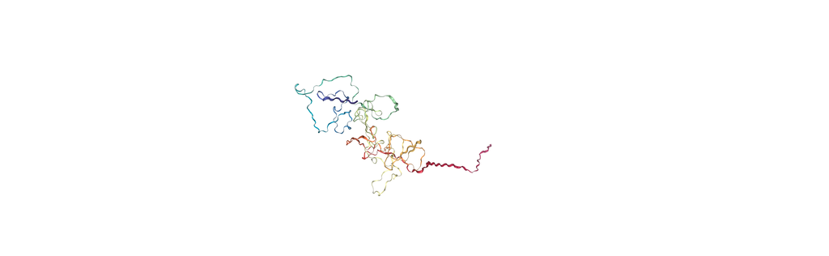

```python
mdl_v._display_image()
```

```python
#model evaluation?
```

Analyzing the Results (15 points)

- 15 points for correctly analyzing the data

Code Formatting Requirements (15 points)

- 5 points for comments identifying global variables and local variables with in depth explanations of each
- 5 points for use of a built-in Bioconductor or Biopython function (or some other tool that was discussed in class like NumPy or SciPy), and description of what the function reads in and what it returns.
- 5 points for hard-coding/redundant code being absent.